# Project 1

Prithviraj Kadiyala

2018-09-21

Abstract

This project is all about analysing the SWDEFECTS file using R and probability theory. We should be able to load data and by writing our own functions calculate the probabilities of Accuracy, Detection Rate, False Alarm Rate and Precision of the system as a whole.Then plot all the Probabilities together to see which method gives us highest probability in detecting the errors or defects in the different complexities of the system.

# 1 Introduction to the Data

## 1.1 Data and variables

```r
swd=read.csv("swdefects.csv")
head(swd)
```

|  | Mloc | Mvg | Mevg | Mivg | Hn | Hvol | Hpgmlen | Hdiff | Hintell | Heffort | Hb | Htime | Hloc | Hcomm | Hblank | loc.comm | uniOp | uniOpnd | totOp | totOpnd | brnchcnt | defect | predict.vg.10 | predict.evg.14.5 | predict.ivg.9.2 | predict.loc.50 |
| --- | --- | --- | --- | --- | --- | --- | --- | --- | --- | --- | --- | --- | --- | --- | --- | --- | --- | --- | --- | --- | --- | --- | --- | --- | --- | --- |
| 1 | 1.1 | 1.4 | 1.4 | 1.4 | 1.3 | 1.3 | 1.30 | 1.30 | 1.30 | 1 | 1.30 | 1 | 2 | 2 | 2 | 2 | 1.2 | 1.2 | 1.2 | 1.2 | 1.4 | FALSE | no | no | no | no |
| 2 | 1.0 | 1.0 | 1.0 | 1.0 | 1.0 | 1.0 | 1.00 | 1.00 | 1.00 | 1 | 1.00 | 1 | 1 | 1 | 1 | 1 | 1.0 | 1.0 | 1.0 | 1.0 | 1.0 | TRUE | no | no | no | no |
| 3 | 24.0 | 5.0 | 1.0 | 3.0 | 63.0 | 309.1 | 0.11 | 9.50 | 32.54 | 2937 | 0.10 | 163 | 1 | 0 | 6 | 0 | 15.0 | 15.0 | 44.0 | 19.0 | 9.0 | FALSE | no | no | no | no |
| 4 | 20.0 | 4.0 | 4.0 | 2.0 | 47.0 | 215.5 | 0.06 | 16.00 | 13.47 | 3448 | 0.07 | 192 | 0 | 0 | 3 | 0 | 16.0 | 8.0 | 31.0 | 16.0 | 7.0 | FALSE | no | no | no | no |
| 5 | 24.0 | 6.0 | 6.0 | 2.0 | 72.0 | 346.1 | 0.06 | 17.33 | 19.97 | 6000 | 0.12 | 333 | 0 | 0 | 3 | 0 | 16.0 | 12.0 | 46.0 | 26.0 | 11.0 | FALSE | no | no | no | no |
| 6 | 24.0 | 6.0 | 6.0 | 2.0 | 72.0 | 346.1 | 0.06 | 17.33 | 19.97 | 6000 | 0.12 | 333 | 0 | 0 | 3 | 0 | 16.0 | 12.0 | 46.0 | 26.0 | 11.0 | FALSE | no | no | no | no |

## 1.2 Summary Table

**Create the summary table (TABLE SIA3.2) found on page 125.**

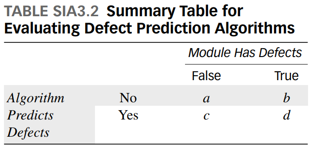

The four Probabilities are:

> 1. Accuracy
> 2. Detection rate
> 3. False alarm rate
> 4. Precision

The formulas are as follows:

$1. Accuracy: P(Algorithm is correct) = \frac{(a+d)}{(a+b+c+d)}$

$2. Detection Rate: P(predict defect|module has defect)=\frac{d}{(b+d)}$

$3. Fals alarm Rate: P(predict defect|module has no defect)=\frac{c}{(a+c)}$

$4. Precision: P(module has defect|predict defect)=\frac{d}{(d+c)}$

# 2 R functions

## 2.1 Function for accuracy

```r
acc=function(a,b,c,d)
{
  accuracy = (a+d)/(a+b+c+d)
  round(accuracy,3)
}
```

## 2.2 Function for detection

```r
detect=function(b,d)
{
  detectionrate = d/(b+d)
  round(detectionrate,3)
}
```

## 2.3 Function for False alarm rate

```r
falarm=function(a,c)
{
  falsealarm = c/(a+c)
  round(falsealarm,3)
}
```

## 2.4 Function for Precision rate

```r
prec=function(c,d)
{
  precision=d/(c+d)
  round(precision,3)
}
```

# 3 Create the tables in Figure SIA3.1

## 3.1 Function to make table

```r
#Creates tables based on the column names given to it.
createtable=function(df,col1,col2, header="Barplot"){
  tab=with(df, table(df[[col1]],df[[col2]]))
  barplot(tab, beside=TRUE, leg=TRUE, main=header)
  tab2=addmargins(tab)
  tab2
}
```

## 3.2 Creating different tables

### 3.2.1 Table for Line of Code

```r
tabloc = createtable(swd,"predict.loc.50","defect", header="Line of Code")
```

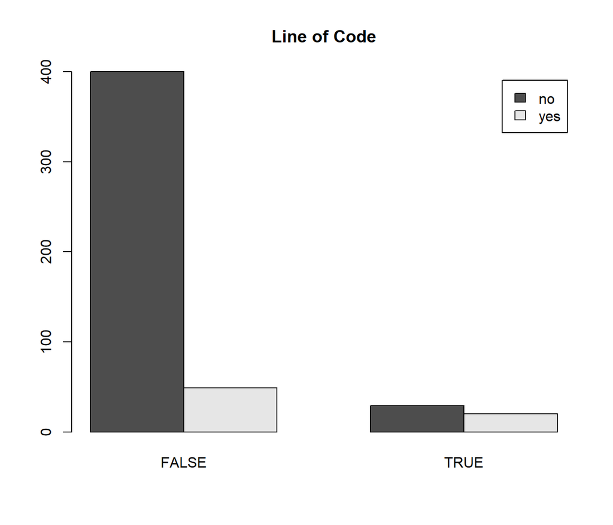

```r
tabloc
```

```
##
##       FALSE TRUE Sum
##   no    400   29 429
##   yes    49   20  69
##   Sum   449   49 498
```

### 3.2.2 Table for Cyclomatic complexity

```r
tabvg = createtable(swd,"predict.vg.10","defect", header="Cyclomatic Complexity")
```

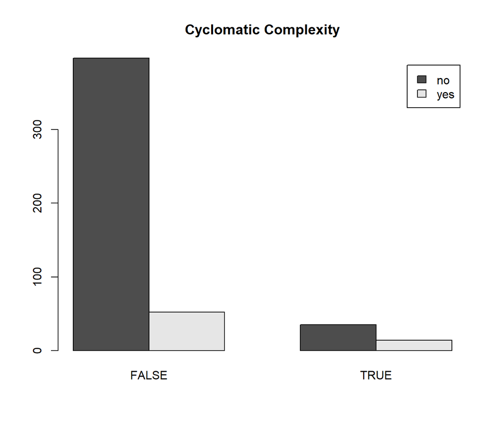

```r
tabvg
```

```
##
##       FALSE TRUE Sum
##   no    397   35 432
##   yes    52   14  66
##   Sum   449   49 498
```

### 3.2.3 Table for Essential Complexity

```r
tabevg = createtable(swd,"predict.evg.14.5","defect", header="Essential Complexity")
```

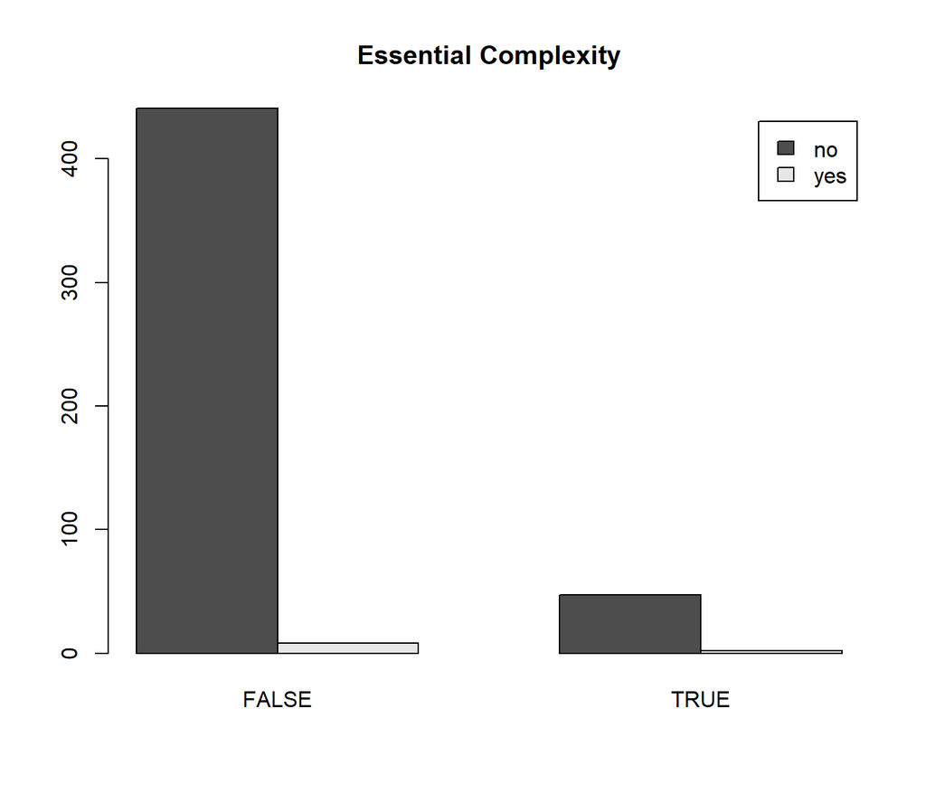

```r
tabevg
```

```
##
##       FALSE TRUE Sum
##   no    441   47 488
##   yes     8    2  10
##   Sum   449   49 498
```

### 3.2.4 Table for Design Complexity

```r
tabivg = createtable(swd,"predict.ivg.9.2","defect", header="Design Complexity")
```

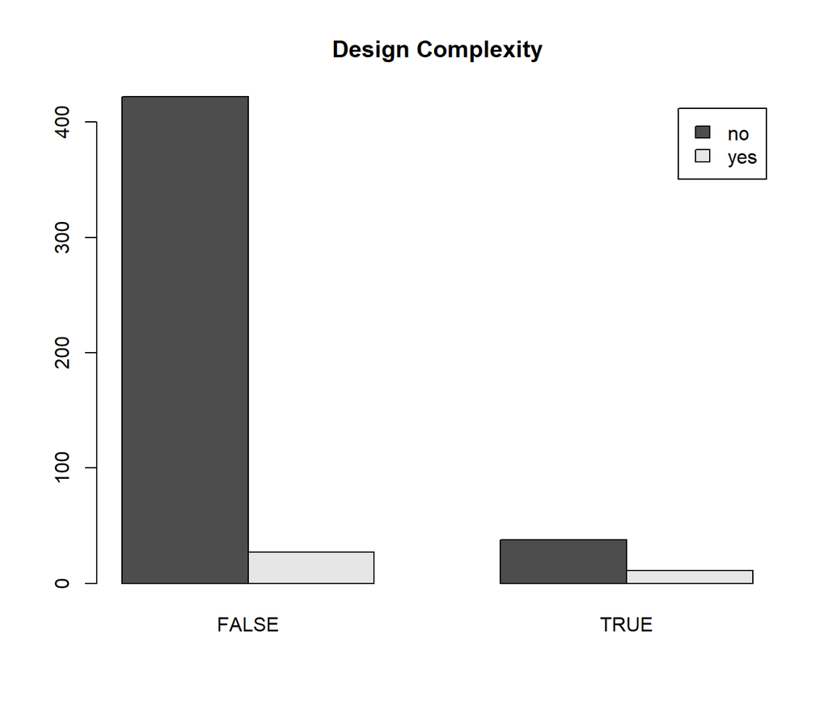

```r
tabivg
```

```
##
##       FALSE TRUE Sum
##   no    422   38 460
##   yes    27   11  38
##   Sum   449   49 498
```

# 4 Create the table

## 4.1 Function to create the table given df

```r
allmethods = function(df) # dataframe
{
  tabloc = createtable(df,"predict.loc.50","defect", header="Line of Code")
  tabvg = createtable(df,"predict.vg.10","defect", header="Cyclomatic Complexity")
  tabevg = createtable(df,"predict.evg.14.5","defect", header="Essential Complexity")
  tabivg = createtable(df,"predict.ivg.9.2","defect", header="Design Complexity")

  probs=c("Accuracy","Detection Rate","False Alarm Rate", "Precision")
  mths = c("Lines of Code", "Cyclomatic complexity", "Essential complexity", "Design complexity")

  mat = matrix(NA, nrow = length(mths), ncol = length(probs), dimnames=list(mths,probs))
  for (i in 1:length(mths)) {
    if(i==1){
      a = tabloc[1,1]
      b = tabloc[1,2]
      c = tabloc[2,1]
      d = tabloc[2,2]
    }
    else if(i==2){
      a = tabvg[1,1]
      b = tabvg[1,2]
      c = tabvg[2,1]
      d = tabvg[2,2]
    }
    else if(i==3){
      a = tabevg[1,1]
      b = tabevg[1,2]
      c = tabevg[2,1]
      d = tabevg[2,2]
    }
    else{
      a = tabivg[1,1]
      b = tabivg[1,2]
      c = tabivg[2,1]
      d = tabivg[2,2]
    }
    #Calculate a,b,c,d here
    for (j in 1:length(probs)) {
      if(j==1){
        mat[i,j] = acc(a,b,c,d)
      }
      else if(j==2){
        mat[i,j] = detect(b,d)
      }
      else if(j==3){
        mat[i,j] = falarm(a,c)
      }
      else{
        mat[i,j] = prec(c,d)
      }
    }
  }
  mat


  as.table(mat)
}

tab=allmethods(df = swd)
```

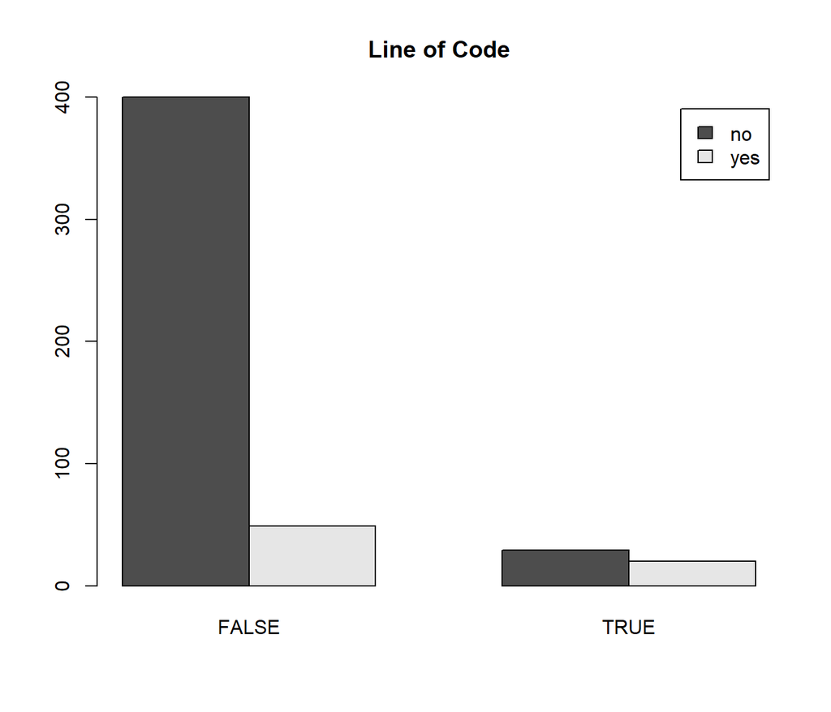

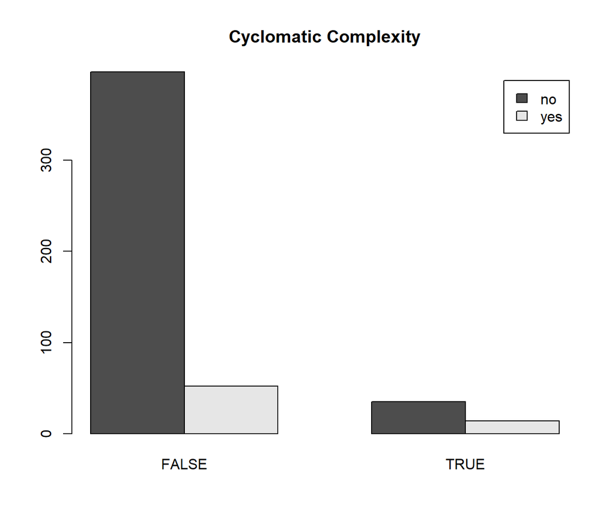

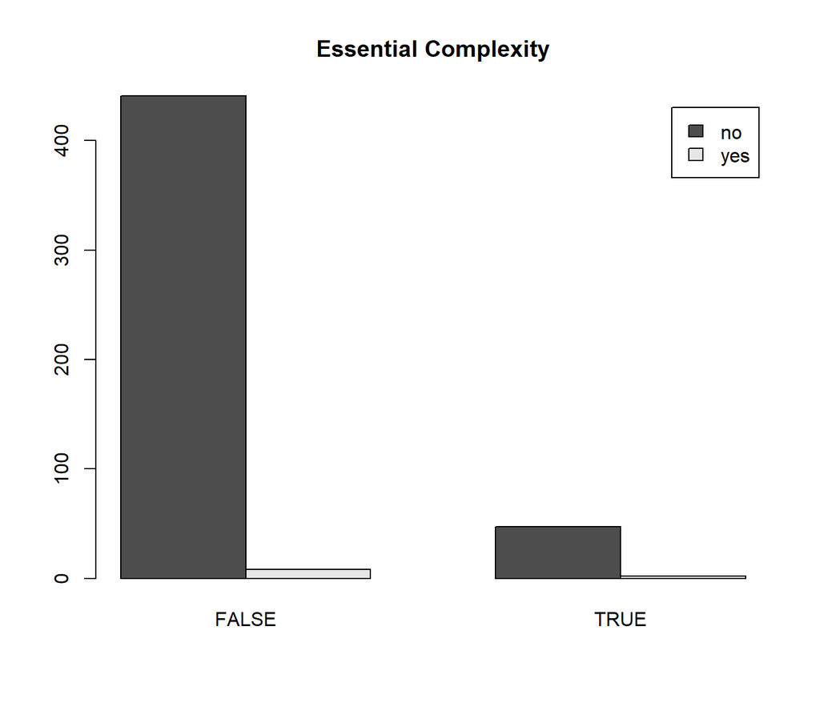

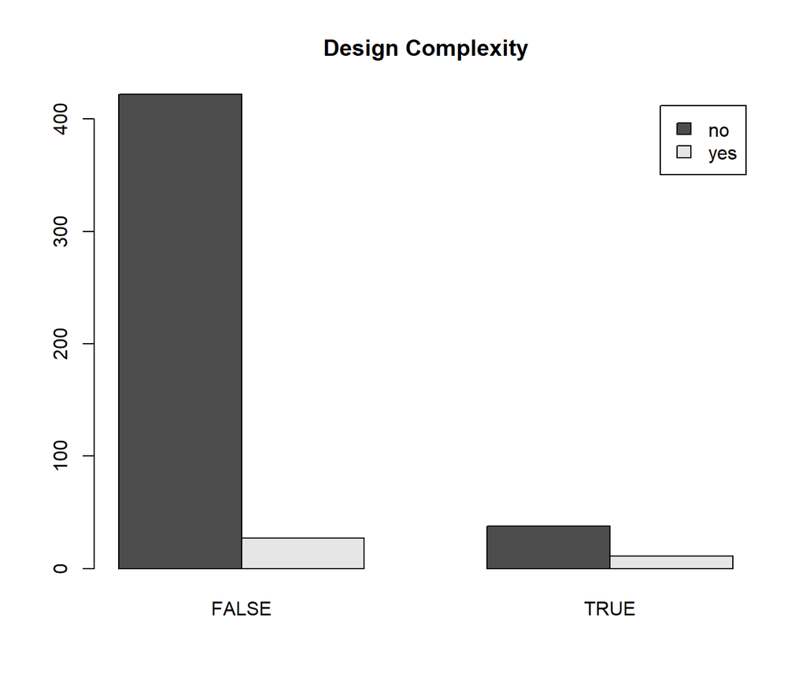

```r
tab
```

```
##                       Accuracy Detection Rate False Alarm Rate Precision
## Lines of Code            0.843          0.408            0.109     0.290
## Cyclomatic complexity    0.825          0.286            0.116     0.212
## Essential complexity     0.890          0.041            0.018     0.200
## Design complexity        0.869          0.224            0.060     0.289
```

## 4.2 Barplot of all the data

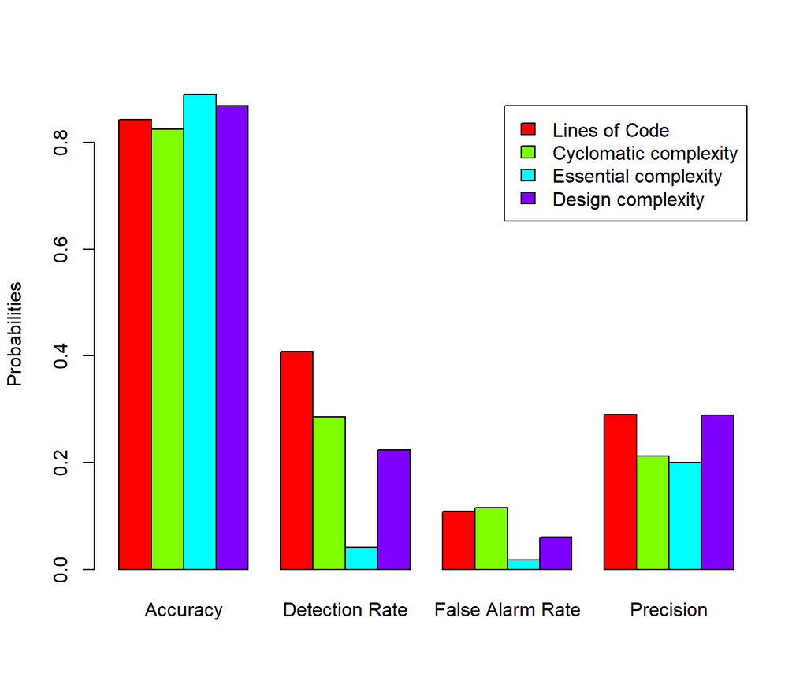

```r
barplot(tab, ylab="Probabilities", beside=TRUE, col=rainbow(4), leg=TRUE)
```